# Capstone Project Milestone Report

Sanchit Sharma

13 January 2018

## Summary of the report

This report is for the Coursera Capstone Project offered by Johns Hopkins Bloomberg School of Public Health. The main objective in this course is to apply data science in the area of natural language processing. The final result of this course will be to construct a Shiny application that accepts some text inputed by the user and try to predict what the next word will be. The report explains my exploratory analysis and my goals for the eventual app and algorithm.

## Loading the required packages

```r
#Loading the required packages
library(tm)
library(stringr)
library(stringi)
library(stylo)
library(RWeka)
library(dplyr)
```

## Preparing the data

The data provided in the course site comprises of four sets of files (de_DE - Danish, en_US - English,fi_FI - Finnish an ru_RU - Russian), with each set containing 3 text files with texts from blogs, news sites and twitter. In this analysis we will focus on the english set of files: en_US.blogs.txt , en_US.news.txt and en_US.twitter.txt.

```r
fileUrl <- "https://d396qusza40orc.cloudfront.net/dsscapstone/dataset/Coursera-SwiftKey.zip"
download.file(fileUrl, destfile = "C:/CapstoneProject/projectdata")
unzip(zipfile = "C:/CapstoneProject/projectdata", exdir = "C:/CapstoneProject")
```

```r
#Reading lines from the US blogs text file into R
con <- file("C:/CapstoneProject/final/en_US/en_US.blogs.txt", "r")
blog <- readLines(con)
close(con)

#Generating a reproducible sample subset from the US blogs text file
set.seed(1)
sampleblog <- blog[rbinom(length(blog)*0.25, length(blog), 0.5)]
write.csv(sampleblog,"C:/CapstoneProject/SampleData/sampleblog.csv", row.names = FALSE,
          col.names = FALSE)
#Reading lines from the US twitter text file into R
con1 <- file("C:/CapstoneProject/final/en_US/en_US.twitter.txt", "r")
twitter <- readLines(con1)
close(con1)

#Generating a reproducible sample subset from the US twitter text file
set.seed(2)
sampletwitter <- twitter[rbinom(length(twitter)*0.25, length(twitter), 0.5)]
write.csv(sampletwitter,"C:/CapstoneProject/SampleData/sampletwitter.csv", row.names = FALSE,
          col.names = FALSE)
#Reading lines from the US news text file into R
con2 <- file("C:/CapstoneProject/final/en_US/en_US.news.txt", "rb")
news <- readLines(con2)
close(con2)

#Generating a reproducible sample subset from the US news text file
set.seed(3)
samplenews <- news[rbinom(length(news)*0.25, length(news), 0.5)]
write.csv(samplenews,"C:/CapstoneProject/SampleData/samplenews.csv", row.names = FALSE,
          col.names = FALSE)
```

## Exploring the three text files

We perform exploratory analysis of the three files. The analysis includes finding the number of lines, number of characters, and number of characters which aren’t white spaces in each file. We also create barplots depicting each of these statistics.

```r
#Displaying general statistics about the sampleblog text file
blogStats <- stri_stats_general(sampleblog)
blogStats
```

```
##       Lines LinesNEmpty       Chars CharsNWhite
##      224822      224822    52425824    43268838
```

```r
#Displaying general statistics about the sampleblog text file
newsStats <- stri_stats_general(samplenews)
newsStats
```

```
##       Lines LinesNEmpty       Chars CharsNWhite
##      252560      252560    50737039    42428930
```

```r
#Displaying general statistics about the sampleblog text file
twitterStats <- stri_stats_general(sampletwitter)
twitterStats
```

```
##       Lines LinesNEmpty       Chars CharsNWhite
##      590037      590037    40473324    33477507
```

```r
#Combining statistics of all files in one variable
DataStats <- rbind(blogStats, newsStats, twitterStats)
DataStats
```

```
##               Lines LinesNEmpty    Chars CharsNWhite
## blogStats    224822      224822 52425824    43268838
## newsStats    252560      252560 50737039    42428930
## twitterStats 590037      590037 40473324    33477507
```

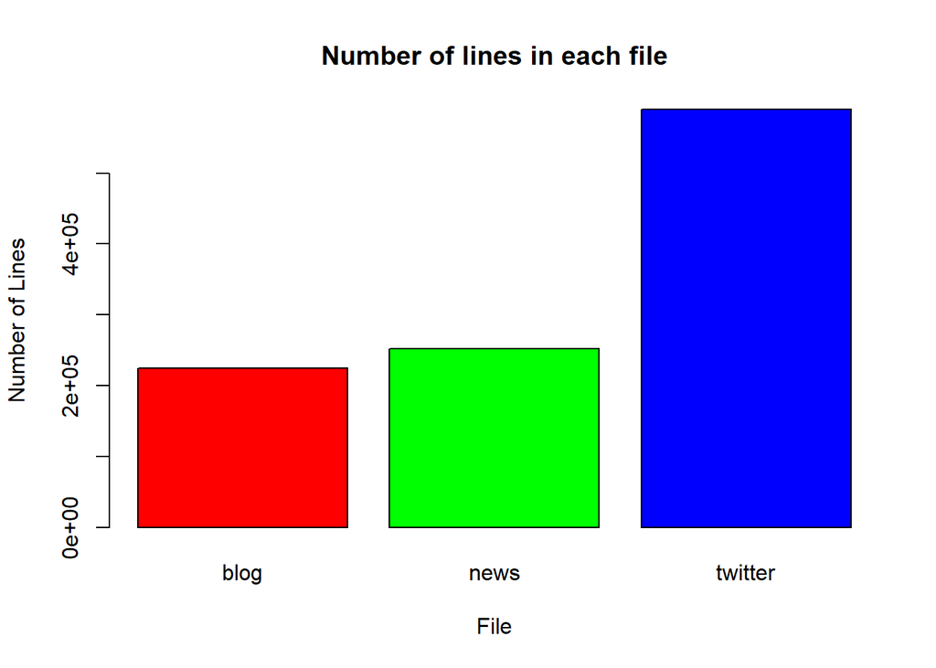

```r
#Converting DataStats into a data frame object
DataStats <- as.data.frame(DataStats)

#Giving rows of the DataStats data fram proper names
rownames(DataStats) <- c("blog", "news", "twitter")

#Creating a barplot depicting the number of lines in each file
barplot(DataStats[,1], names.arg = rownames(DataStats), main = "Number of lines in each file", xlab = "File", ylab =
          "Number of Lines", col = c("red", "green", "blue"))
```

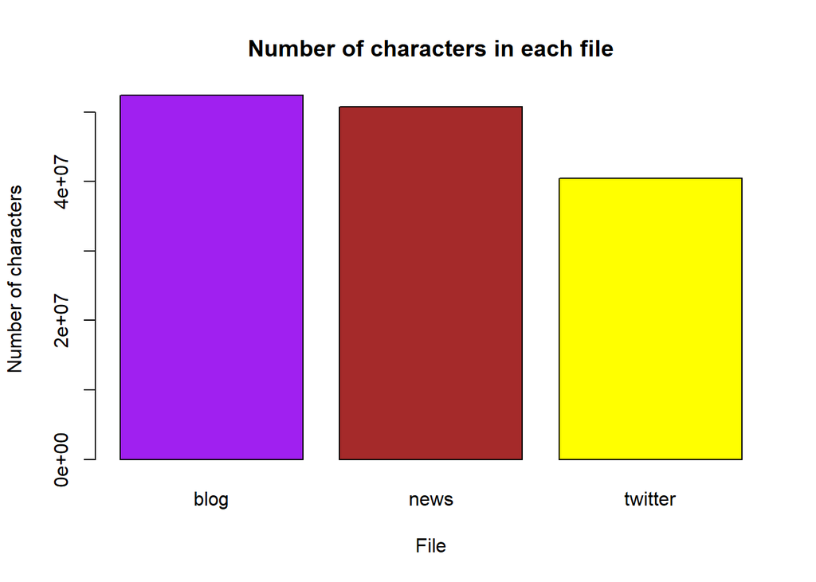

```r
#Creating a barplot depicting the number of characters in each file
barplot(DataStats[,3], names.arg = row.names(DataStats), main = "Number of characters in each file", xlab = "File", ylab =
          "Number of characters", col = c("purple", "brown", "yellow"))
```

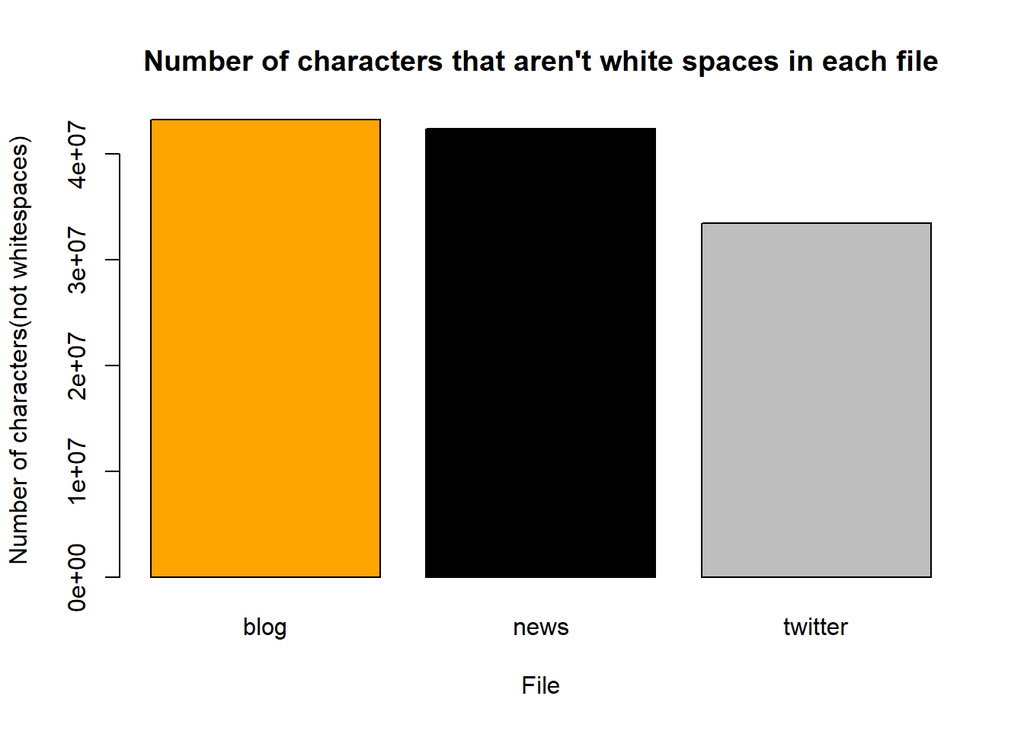

```r
#Creating a barplot depicting the number of  that aren't white spaces in each file
barplot(DataStats[,4], names.arg = row.names(DataStats), main = "Number of characters that aren't white spaces in each file", xlab = "File", ylab =
          "Number of characters(not whitespaces)", col = c("orange", "black", "grey"))
```

## Building a corpus

Data from the 3 files are merged together and a text corpus is built using the tm library.

```r
#Combining all 3 sample subsets into a Corpus
SampleData <- VCorpus(DirSource("C:/CapstoneProject/SampleData/"), readerControl = list(language="en_US"))
```

## Exploring the corpus

We perform exploratory analysis of the corpus.

```r
#Printing out the number of documents in the corpus
length(SampleData)
```

```
## [1] 3
```

```r
#Printing out the details of the corpus
summary(SampleData)
```

```
##                   Length Class             Mode
## sampleblog.csv    2      PlainTextDocument list
## samplenews.csv    2      PlainTextDocument list
## sampletwitter.csv 2      PlainTextDocument list
```

```r
#Printing out the metadata of each document in the corpus
meta(SampleData[[1]])
```

```
##   author       : character(0)
##   datetimestamp: 2018-01-15 05:55:17
##   description  : character(0)
##   heading      : character(0)
##   id           : sampleblog.csv
##   language     : en_US
##   origin       : character(0)
```

```r
meta(SampleData[[2]])
```

```
##   author       : character(0)
##   datetimestamp: 2018-01-15 05:55:17
##   description  : character(0)
##   heading      : character(0)
##   id           : samplenews.csv
##   language     : en_US
##   origin       : character(0)
```

```r
meta(SampleData[[3]])
```

```
##   author       : character(0)
##   datetimestamp: 2018-01-15 05:55:17
##   description  : character(0)
##   heading      : character(0)
##   id           : sampletwitter.csv
##   language     : en_US
##   origin       : character(0)
```

```r
#Printing out the number of characters in each document of the corpus
length(SampleData[[1]]$content)
```

```
## [1] 224823
```

```r
length(SampleData[[2]]$content)
```

```
## [1] 252561
```

```r
length(SampleData[[3]]$content)
```

```
## [1] 590038
```

```r
#Printing first line of each document in the corpus
SampleData[[1]]$content[2]
```

```
## [1] "\"My third card in my series of \"\"Same But Different\"\", is using the image \"\"You're sew nice..\"\", and as I have said it is from Pamela's blog, \"\"Free Vintage Digi Stamps\"\". Here is a pic.\""
```

```r
SampleData[[2]]$content[2]
```

```
## [1] "\"(05-01) 19:00 PDT SAN DIEGO, (AP) --\""
```

```r
SampleData[[3]]$content[2]
```

```
## [1] "\"I don't think you ready now.\""
```

## Cleaning the corpus

```r
#Removing urls from each file in the corpus
removeUrl <- content_transformer(function(x, pattern) gsub(pattern, '', x, ignore.case = TRUE))
SampleData <- tm_map(SampleData, removeUrl, '(ftp|http)\\S+\\s*')

#Removing e-mail ids from each file in the corpus
removeEmail <- content_transformer(function(x, pattern) str_replace_all(x, pattern, ''))
SampleData <- tm_map(SampleData, removeEmail, "[a-zA-Z0-9_.+-]+@[a-zA-Z0-9-]+\\.[a-zA-Z0-9-.]+")

#Removing twitter tags from each file in the corpus
removeTT <- content_transformer(function(x, pattern) gsub(pattern, '', x))
SampleData <- tm_map(SampleData, removeTT, "RT |via")

#Removing twitter hash tags from each file in the corpus
removeHT <- content_transformer(function(x, pattern) gsub(pattern, '', x))
SampleData <- tm_map(SampleData, removeHT, "#[a-z,A-Z]*")

#Removing html entities from corpus
removeAmp <- content_transformer(function(x, pattern) gsub(pattern, '', x))
SampleData <- tm_map(SampleData, removeAmp, "&amp")

#Removing numbers from each file in the corpus
SampleData <- tm_map(SampleData, removeNumbers)

#Removing punctuation from each file in the corpus
SampleData <- tm_map(SampleData, removePunctuation)

#Removing anything else other than english alphabet from each file in the corpus
removeNonAlphaChar <- content_transformer(function(x, pattern) gsub(pattern, " ", x))
SampleData <- tm_map(SampleData, removeNonAlphaChar, '[^a-zA-Z]')

#Removing stop words from each file in the corpus
SampleData <- tm_map(SampleData, removeWords, stopwords("en"))

#Converting text to lower case
SampleData <- tm_map(SampleData, content_transformer(tolower))

#Removing single letters which don't make sense from each text file in corpus
letters <- read.table("letters.txt", header = FALSE, quote = "", sep = "\n", strip.white = TRUE)
SampleData <- tm_map(SampleData, removeWords, letters[,1])

#Removing profane words from each text file in the corpus
profaneWords <- read.table("bad_words.txt", header = FALSE, quote = "", sep = "\n", strip.white = TRUE)
SampleData <- tm_map(SampleData, removeWords, profaneWords[,1])

#Removing extra whitespace from the corpus
SampleData <- tm_map(SampleData, stripWhitespace)
```

### Most frequent words in the corpus

```r
#Convert corpus into a vector of text
myData <- txt.to.words(SampleData)

#Displaying the 100 most frequent words in the entire corpus
freqlist <- make.frequency.list(myData, head = 100)
freqlist
```

```
##   [1] "i"         "the"       "will"      "said"      "just"
##   [6] "one"       "like"      "get"       "can"       "new"
##  [11] "time"      "now"       "im"        "day"       "know"
##  [16] "good"      "love"      "it"        "people"    "us"
##  [21] "back"      "also"      "going"     "today"     "but"
##  [26] "and"       "first"     "great"     "make"      "last"
##  [31] "well"      "two"       "go"        "dont"      "see"
##  [36] "think"     "we"        "much"      "year"      "in"
##  [41] "you"       "a"         "got"       "want"      "thanks"
##  [46] "way"       "he"        "really"    "even"      "work"
##  [51] "best"      "this"      "if"        "right"     "say"
##  [56] "so"        "little"    "years"     "still"     "come"
##  [61] "life"      "night"     "week"      "its"       "take"
##  [66] "made"      "may"       "things"    "next"      "need"
##  [71] "what"      "thats"     "another"   "game"      "many"
##  [76] "something" "they"      "never"     "school"    "big"
##  [81] "around"    "state"     "home"      "lol"       "cant"
##  [86] "my"        "use"       "world"     "sure"      "th"
##  [91] "follow"    "team"      "always"    "that"      "better"
##  [96] "help"      "ever"      "lot"       "happy"     "pm"
```

## Creating unigram model and plotting the frequency of top 50 frequent words

Here we find the frequency and the probabilities of each word or unigram in the corpus. We arrange them according to the descending order of their probabilities and create a barplot depicting the frequency of the top 50 most frequent words.

```r
#Creating unigram model
term_doc_mat <- TermDocumentMatrix(SampleData)
term_doc_mat <- removeSparseTerms(term_doc_mat, 0.54)
a <- as.matrix(term_doc_mat)
b <- rowSums(a)
unigram <- as.data.frame(b)
colnames(unigram) <- c("freq")
unigram$term <- rownames(unigram)
unigram$prob <-with(freq/sum(freq),data=unigram)
unigram <- arrange(unigram,desc(prob))

#Exploring the unigram model
dim(unigram)
```

```
## [1] 9608    3
```

```r
summary(unigram)
```

```
##       freq            term                prob
##  Min.   :     2   Length:9608        Min.   :1.650e-07
##  1st Qu.:   207   Class :character   1st Qu.:1.706e-05
##  Median :   441   Mode  :character   Median :3.635e-05
##  Mean   :  1263                      Mean   :1.041e-04
##  3rd Qu.:  1025                      3rd Qu.:8.449e-05
##  Max.   :126171                      Max.   :1.040e-02
```

```r
str(unigram)
```

```
## 'data.frame':    9608 obs. of  3 variables:
##  $ freq: num  126171 84118 77092 74720 70773 ...
##  $ term: chr  "the" "will" "said" "just" ...
##  $ prob: num  0.0104 0.00693 0.00635 0.00616 0.00583 ...
```

```r
#Displaying first 10 rows of unigram model
head(unigram, 10)
```

```
##      freq term        prob
## 1  126171  the 0.010400014
## 2   84118 will 0.006933672
## 3   77092 said 0.006354534
## 4   74720 just 0.006159015
## 5   70773  one 0.005833671
## 6   67497 like 0.005563638
## 7   59716  get 0.004922266
## 8   58958  can 0.004859786
## 9   53021  new 0.004370411
## 10  51802 time 0.004269931
```

```r
#Displaying last 10 rows of unigram model
tail(unigram, 10)
```

```
##      freq         term         prob
## 9599    2   artificial 1.648558e-07
## 9600    2         cara 1.648558e-07
## 9601    2 certificates 1.648558e-07
## 9602    2         dorm 1.648558e-07
## 9603    2    formation 1.648558e-07
## 9604    2          int 1.648558e-07
## 9605    2     performs 1.648558e-07
## 9606    2     sidewalk 1.648558e-07
## 9607    2    stumbling 1.648558e-07
## 9608    2    telegraph 1.648558e-07
```

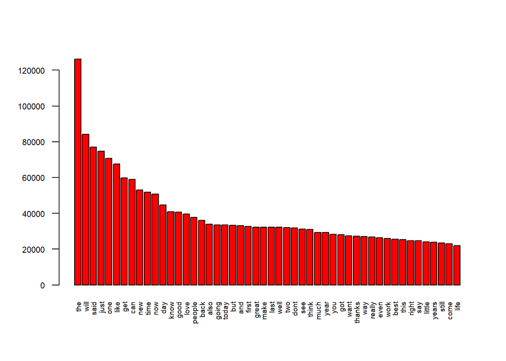

```r
#Plotting the frequency of top 50 words in the corpus
barplot(unigram[1:50,1], names.arg = unigram[1:50,2], cex.names = 0.60, cex.axis = 0.70, col = "red", las = 2)
```

## Next steps for prediction and shiny app

This concludes our exploratory analysis. Our next step is to finalize our predictive algorithm, and to deploy that algorithm as a shiny app.

Our predictive algorithm will be based on the n-gram model with frequency lookup similar to the exploratory analysis that we have conducted above.

We will create the bigram and trigram models and use the trigram model to predict the next word. If no matching trigram can be found, then the algorithm would use the bigram model, and then the unigram model if needed. Katz backoff model is an approach we can use to handle cases where a particular ngram isnt observed within our data set.

The user interface of the shiny app will consist of a text input box that will allow a user to enter a phrase. Then the app will use our algorithm to suggest the most likely next word.